# 1.5.2 - Beginner - Introduction to Data Visualization II

econ 325

visualization

ggplot

graphs

beginner

R

labels

scales

faceting

confidence bands

How do we make visualizations of data? This notebook uses the `ggplot` packages to help create impactful data visualizations using R. This builds on the first notebook, introducing more complex visualizations and techniques.

Author

COMET Team  
*Anneke Dresselhuis, Jonathan Graves*

Published

12 January 2023

## Outline

### Prerequisites

- Introduction to Jupyter
- Introduction to R
- Introduction to Data Visualization 1

### Outcomes

By the end of this notebook, you will be able to:

- Customize aesthetic labels on a graph to communicate the key message of a visualization
- Use faceted graphs to visually represent complex data
- Identify best practices for creating effective visualizations
- Recognize ways in which visualizations can be used nefariously

### References

- Deeb, Sameer. 2005. “The Molecular Basis of Variation in Human Color Vision.” *Clinical Genetics* 67: 369–77.

## Introduction

This notebook expands on the concepts introduced in Introduction to Data Visualization 1 and explores ways to create more layering customizations that can help make our visualizations look extra polished.

> **Note**: we use a substantial amount of charts in this notebook. If the charts are not rendering properly, try adjusting the following parameters in the plot codes: options(repr.plot.width = 15, repr.plot.height = 9). `repr.plot.width` is the plot width and `repr.plot.height` is the plot height.

We’ll also see how our new tools perform in a few case study examples.

Because we’re already familiar with the theoretical concepts of `ggplot2`, **this notebook serves as more of a** **resource guide with practical case study examples than as a learning module.**

In this notebook, we’ll be working with the Penn World Tables data set again. Let’s load it now.

```r
source("beginner_intro_to_data_visualization2_tests.r")
```

```r
# import packages
library(tidyverse) # contains ggplot2, which is what we'll be using!
library(haven)
library(RColorBrewer)
library(ggthemes)

# library(lubridate)

# load the data
pwt_data <- read_dta("../datasets_beginner/pwt100.dta")

# declare factors
pwt_data <- as_factor(pwt_data)

pwt_data <- pwt_data %>%
    mutate(countrycode = as.factor(countrycode)) %>%
    mutate(country = as.factor(country)) %>%
    mutate(currency_unit = as.factor(currency_unit))

NA_data <- filter(pwt_data, (countrycode == "CAN")|(countrycode == "USA"))

# check that it looks OK
tail(NA_data,10)
```

```
# A tibble: 10 × 52
   countrycode country currency_unit  year  rgdpe  rgdpo   pop   emp   avh    hc
   <fct>       <fct>   <fct>         <dbl>  <dbl>  <dbl> <dbl> <dbl> <dbl> <dbl>
 1 USA         United… US Dollar      2010 1.66e7 1.67e7  309.  141. 1735.  3.70
 2 USA         United… US Dollar      2011 1.68e7 1.69e7  312.  142. 1745.  3.71
 3 USA         United… US Dollar      2012 1.73e7 1.74e7  314.  145. 1747.  3.71
 4 USA         United… US Dollar      2013 1.77e7 1.78e7  316.  146. 1753.  3.72
 5 USA         United… US Dollar      2014 1.82e7 1.82e7  319.  148. 1758.  3.72
 6 USA         United… US Dollar      2015 1.89e7 1.88e7  321.  150. 1770.  3.73
 7 USA         United… US Dollar      2016 1.93e7 1.91e7  323.  152. 1767.  3.73
 8 USA         United… US Dollar      2017 1.98e7 1.95e7  325.  155. 1764.  3.74
 9 USA         United… US Dollar      2018 2.04e7 2.02e7  327.  157. 1775.  3.74
10 USA         United… US Dollar      2019 2.09e7 2.06e7  329.  158. 1765.  3.75
# ℹ 42 more variables: ccon <dbl>, cda <dbl>, cgdpe <dbl>, cgdpo <dbl>,
#   cn <dbl>, ck <dbl>, ctfp <dbl>, cwtfp <dbl>, rgdpna <dbl>, rconna <dbl>,
#   rdana <dbl>, rnna <dbl>, rkna <dbl>, rtfpna <dbl>, rwtfpna <dbl>,
#   labsh <dbl>, irr <dbl>, delta <dbl>, xr <dbl>, pl_con <dbl>, pl_da <dbl>,
#   pl_gdpo <dbl>, i_cig <fct>, i_xm <fct>, i_xr <fct>, i_outlier <fct>,
#   i_irr <fct>, cor_exp <dbl>, statcap <dbl>, csh_c <dbl>, csh_i <dbl>,
#   csh_g <dbl>, csh_x <dbl>, csh_m <dbl>, csh_r <dbl>, pl_c <dbl>, …
```

```r
# there will be a lot of missing data
```

## Part 1: Adding to our Data Visualization Toolkit

In notebook 1 we introduced the `labs()` function which allows us to specify the aesthetic outputs of different labels on our chart, such as the x and y axis titles, the legend title and main graph title.

Here are a few best practices to keep in mind when crafting and adding labels to charts (pulled from [FusionCharts 2022](https://www.fusioncharts.com/resources/charting-best-practices/5-tips-for-writing-chart-captions)):

- Graph title: should summarize the graph in short, understandable language that is as objective as possible - avoid using unnecessary words such as “the”, “a”, or “an”, as well as adjectives like “amazing” or “poor” which can manipulate your reader’s perception of the graphic.
  - Example: *“Online Grocery Order Growth 2018 vs 2020”* (a better title) vs *“The Significant Growth in Online Grocery Orders in the years 2018 and 2020”* (a worse title)
- Graph subtitle: should be used to add helpful supplemental information that will help your audience understand the graph.
  - Example: Units of measurement, time frames (if this is secondary information)
- Axis Labels: units of measurement should always be made known! If the data is labeled inside the visualization, sometimes axis labels are not necessary - we should always ask ourselves: what does our audience need to know?

Here, we explore a few tips and tricks for customizing labels to suit the needs of our graph.

### The `labs()` function

As a refresher, a few `labs()` arguments we’ve already covered are:

- `x =` specifies x-axis title
- `y =` specifies y-axis title
- `color =` specifies meaning of color outline.
- `fill =` specifies meaning of color fill
- `title =` specifies title of plot

And here are some **new arguments**:

- `subtitle =` specifies a subtitle for the graph (positioned below title)
- `caption =` specifies a caption at the bottom of graph, which can be great for listing the source of our data

These arguments give us a basic infrastructure for a plot - we can demonstrate these features using a simple bar chart.

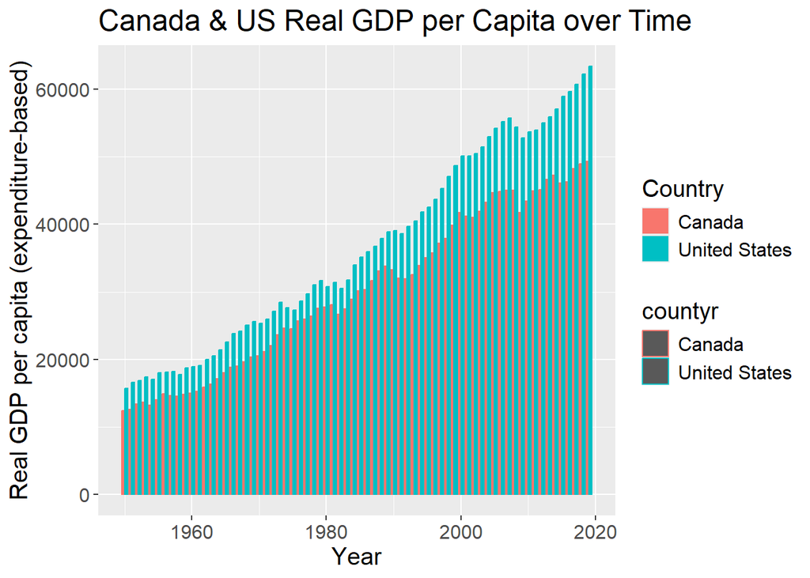

```r
basic_plot <- ggplot(data = NA_data,
                aes(x = year,
                    y = rgdpe/pop,
                    fill = country, # specifies the fill to be by country
                    color = country)) + # specifies the outline to also be by country
        labs(x = "Year",
             y = "Real GDP per capita (expenditure-based)",
             fill = "Country",
             color = "countyr",
             title = "Canada & US Real GDP per Capita over Time") +
        geom_col(position = "dodge") +
        theme(text = element_text(size = 15)) # specifies the x, y and legend label text size
        options(repr.plot.width = 15, repr.plot.height = 9) # specifies the dimension

basic_plot
```

### Test your knowledge

Fix the typo from the graph above (in the code below!) so that the two legends on the right hand side are merged into one.

> **Hint**: remember that arguments in the `ggplot()` contain aesthetic mappings, while arguments in the `labs()` function contain labels and other specifications that are set by us and not the data.

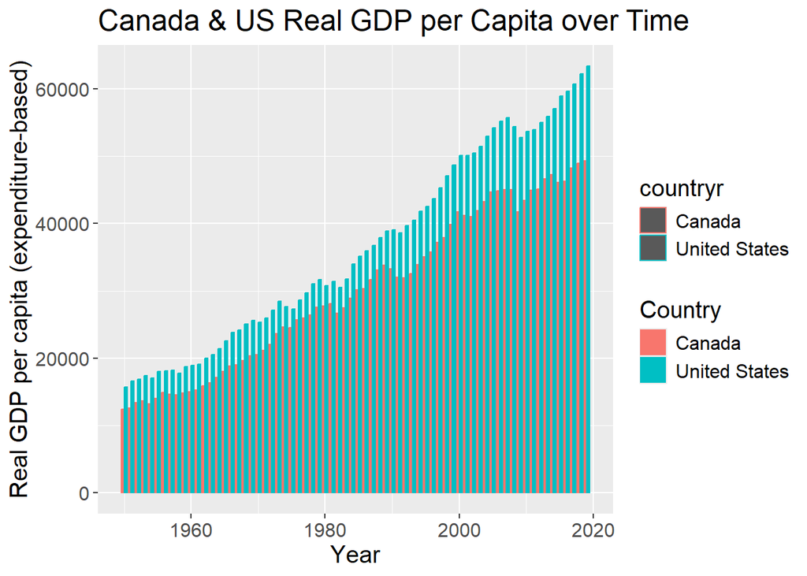

```r
# replace the variable that is causing the error in the legend formatting by the correct variable

basic_plot_test <- ggplot(data = NA_data,
                    aes(x = year,
                    y = rgdpe/pop,
                    fill = country, # specifies the fill to be by country
                    color = country)) + # specifies the outline to also be by country
        labs(x = "Year",
             y = "Real GDP per capita (expenditure-based)",
             fill = "Country",
             color = "countryr",
             title = "Canada & US Real GDP per Capita over Time") +
        geom_col(position = "dodge") +
        theme(text = element_text(size = 15)) # specifies the x, y and legend label text size
        options(repr.plot.width = 15, repr.plot.height = 9) # specifies the dimension

basic_plot_test
```

```r
answer_1 <- basic_plot_test

test_1()
```

## Part 2: Adjusting Features of our Visualization

We also learned about the `theme()` function, which allows us to modify components of a theme such as text. One `theme()` argument we’ve already covered is `text = element_text()`, which specifies text attributes that broadly apply to all text components in a graph (titles, labels, captions, …).

And here are some **new arguments**:

- `plot.title = element_text()` allows specifications for the title text.
- `plot.subtitle.title = element_text()` allows specifications for the subtitle text.
- `plot.caption = element_text()` allows specifications for the caption text.
- `axis.text.x = element_text()` allows specifications for x axis text.
- `axis.text.y = element_text()` allows specifications for y axis text.
- `legend.position =` allows specifications for legend position.
  - Example: `"top"`, `"bottom"` or as a vector (i.e., `c(x-coordinate, y-coordinate)`)
- Always ensure that the text is readable to an audience with a range of seeing abilities.
- Adjusting label size and boldness can help us emphasize important information about a graph that we’d like our audience to focus on. Check out more `theme()` arguments in [this documentation resource created by R Studio](https://ggplot2.tidyverse.org/reference/theme.html).

### The `element_text()` function

There are also a quite a few things we can specify using the `element_text()` function:

- `size =` specifies x-axis title (default in R is set at size 11).
- `hjust =` specifies the position of the plot titles (default is left).
  - `0.5`: centre, `1`: right, `0`: left
- `color =` specifies the text color.
- `face =` specifies typographical emphasis.
  - Example: `"bold"`, `"italic"`, `"bold.italic"`
- `angle =` specifies angular rotation of text.
- `vjust =` specifies the vertical adjustment.
  - Example: higher number is up, lower number is down from the graph (default is 0).

Let’s use some of these new functions and arguments to improve our earlier visualization!

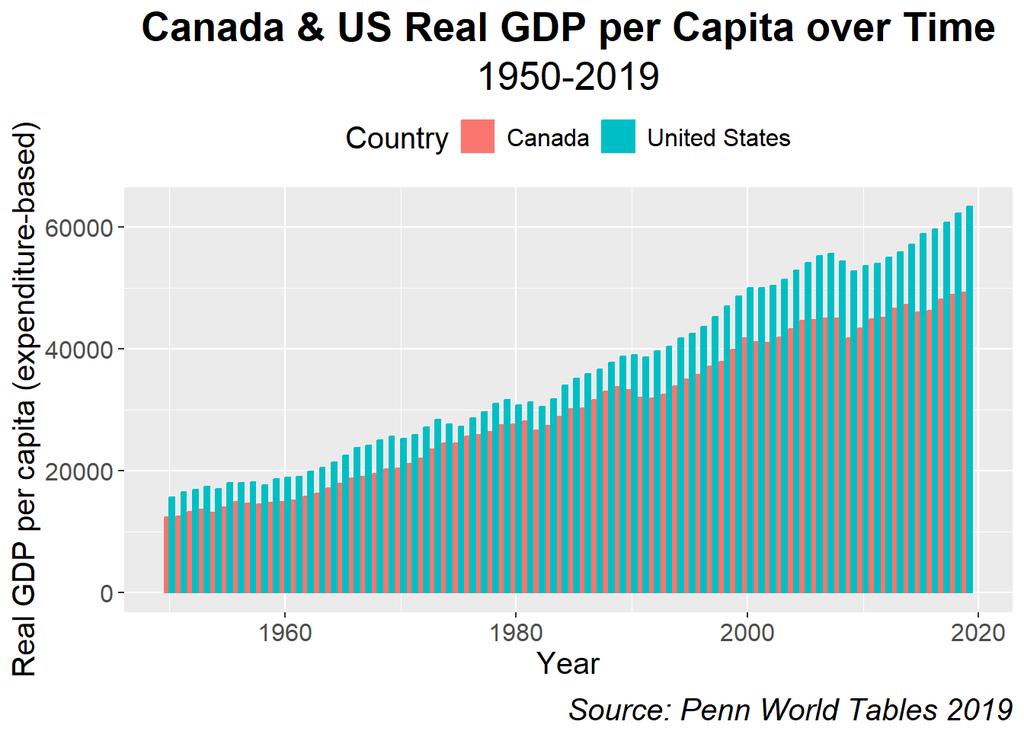

```r
intermediate_plot <- ggplot(data = NA_data,
                aes(x = year,
                    y = rgdpe/pop,
                    fill = country,
                    color = country,
                    geom_text(mapping = country))) +
        labs(x = "Year",
             y = "Real GDP per capita (expenditure-based)",
             fill = "Country",
             color = "Country",
             title = "Canada & US Real GDP per Capita over Time", subtitle = "1950-2019",
             caption = "Source: Penn World Tables 2019") +
        geom_col(position = "dodge") +
        theme(text = element_text(size = 15)) + # specifies the x, y and legend label text size
        theme(plot.title = element_text(size = 20, hjust = 0.5, color = "black", face = "bold")) + # specifies title text details
        theme(plot.subtitle = element_text(size = 19, hjust = 0.5)) +  # specifies subtitle text details
        theme(plot.caption = element_text(size = 15, face = "italic", vjust = 0)) + # specifies caption text details
        theme(legend.position = "top")  # places the legend at the top of the graph
        options(repr.plot.width = 15, repr.plot.height = 9)

intermediate_plot
```

### Scales

To visualize only a subsection of our data we can use the following commands which manipulate the scale of our graphs:

- `xlim()` specifies scale adjustments on the x-axis.
- `ylim()` specifies scale adjustments on the y-axis.

Both of these functions take two arguments - one lower bound limit and one upper bound limit.

- We can use the `xlim()` and `ylim()` functions to examine subsections of our axis variables.
- In the GDP per capita over time plot that we’ve been working with, use `xlim()` to view a subsection of data from 2000-2019 below. This will make the power of changing the scale of our graph much more obvious.

> **Note**: scaling can occur on any quantitative attribute; that is, we can scale other variables in addition to year.

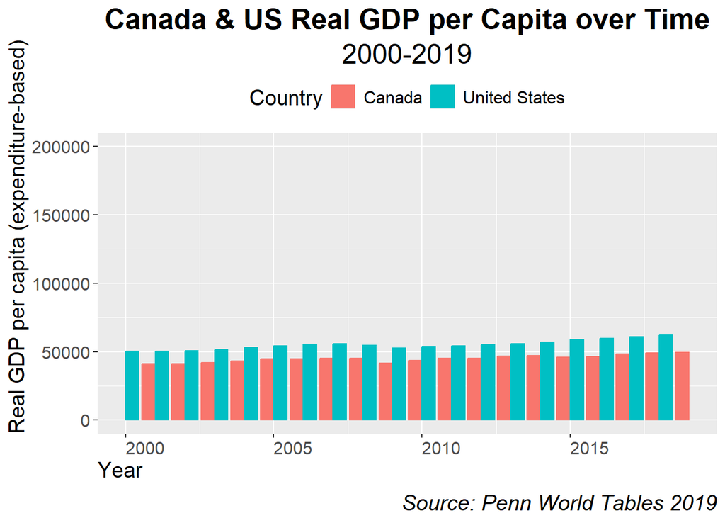

```r
scaled_plot <- ggplot(data = NA_data,
                aes(x = year,
                    y = rgdpe/pop,
                    fill = country,
                    color = country)) +
        labs(x = "Year",
             y = "Real GDP per capita (expenditure-based)",
             fill = "Country",
             color = "Country",
             title = "Canada & US Real GDP per Capita over Time", subtitle = "2000-2019",  # adjust the subtitle to reflect the window of time we're working with
             caption = "Source: Penn World Tables 2019") +
        geom_col(position = "dodge") +
        theme(text = element_text(size = 15, hjust = 0)) +
        theme(plot.title = element_text(size = 20, hjust = 0.5, color = "black", face = "bold")) +
        theme(plot.subtitle = element_text(size = 19, hjust = 0.5)) +
        theme(plot.caption = element_text(size = 15, face = "italic", vjust = 0)) +
        theme(legend.position = "top") +
        xlim(2000,2019) + # adjust x-axis scale with lower bound = 2000 and upper bound = 2019
        ylim(0,200000) # adjust the max y value to 200,000 rather than the automatic scale of ~64,000
        options(repr.plot.width = 15, repr.plot.height = 9)

scaled_plot
```

*What do you notice about this graph? How do the oscillations (ups and downs) appear different when zoomed in here versus in the large view in the other visualization?*

**🔎 **Let’s think critically**

> 🟠 What are some good reasons why we might want to adjust the scale limits of our axis?  
> 🟠 Is there a subsection of data that would be of interest? Why?  
> 🟠 Are we trying to make our oscillations seem less volatile (as seen above) to prove a point? What point?  
> 🟠 Are our scale choices helping our audience gain an understanding of the data that is as objective and accurate as possible?

Scaling is important because it can communicate a variety of different messages depending on how it is used.

### Faceting

Let’s say instead of creating one plot at a time, we’re interested in piecing together a visualization that takes on a more dashboard-like effect to display multiple plots in a grid simultaneously.

- A function we can use to achieve this is `facet_grid()`. To *facet* something simply means to split it.
- Faceting allows us to arrange graphs into multiple views or layers which can help us explore multidimensionality and visualize complexity in a dataset.

Some arguments of `facet_grid()` are:

- `facet_grid(rows = vars(variable))` creates a grid of plots using a variable or variables split into rows (horizontal split) or columns (vertical split).
- The `vars()` function allows our variable(s) of choice to be correctly evaluated in the context of the data frame.
- `geom_hline()` creates a *horizontal* line across our plot(s) at a y value of our choosing.
- `geom_vline()` creates a *vertical* line across our plot(s) at an x value of our choosing.

Both `geom_hline()` and `geom_vline()` can be used on single plots and subplots to emphasize particular thresholds, values or time periods. In the graph below, we’ll add a horizontal line to our faceted plot to help us see when the GDP from each G7 country rose above 40,000.

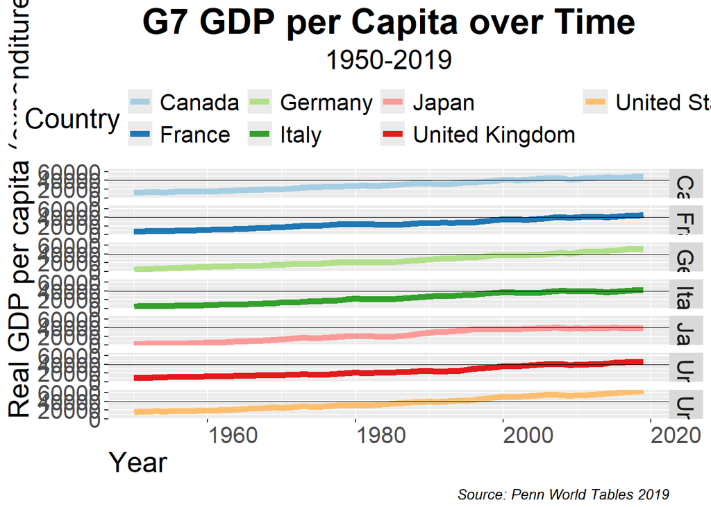

```r
g7_data <- pwt_data %>%
filter(country == "Canada" | country == "United States" | country == "France" |
       country == "Germany" |  country == "Italy" |  country == "Japan" | country == "United Kingdom")  # select G7 countries

facet_plot <- ggplot(data = g7_data,
                aes(x = year,
                    y = rgdpe/pop,
                    fill = as_factor(country),
                    color = country)) +
        labs(x = "Year",
             y = "Real GDP per capita (expenditure-based)",
             fill = "Country",
             color = "Country",
             title = "G7 GDP per Capita over Time", subtitle = "1950-2019",
             caption = "Source: Penn World Tables 2019") +
        geom_line(size = 2) +
        theme(text = element_text(size = 18, hjust = 0)) +
        theme(text = element_text(size = 20, hjust = 0)) +
        theme(plot.title = element_text(size = 25, hjust = 0.5, color = "black", face = "bold")) +
        theme(plot.subtitle = element_text(size = 19, hjust = 0.5)) +
        theme(plot.caption = element_text(size = 10, face = "italic", vjust = 0)) +
        theme(legend.position = "top") +
        geom_hline(yintercept = 40000, linetype = "solid", size = 0.25) + # add horizontal line
        facet_grid(rows = vars(country)) + # create a set of subplots organized by country
        scale_color_brewer(palette="Paired")
        options(repr.plot.width = 15, repr.plot.height = 9)


facet_plot
```

Faceting allows us to arrange charts to make comparisons clearly. Without faceting, a consolidated line chart of all G7 countries such as the one below might look overcrowded and difficult to observe the nuances between countries.

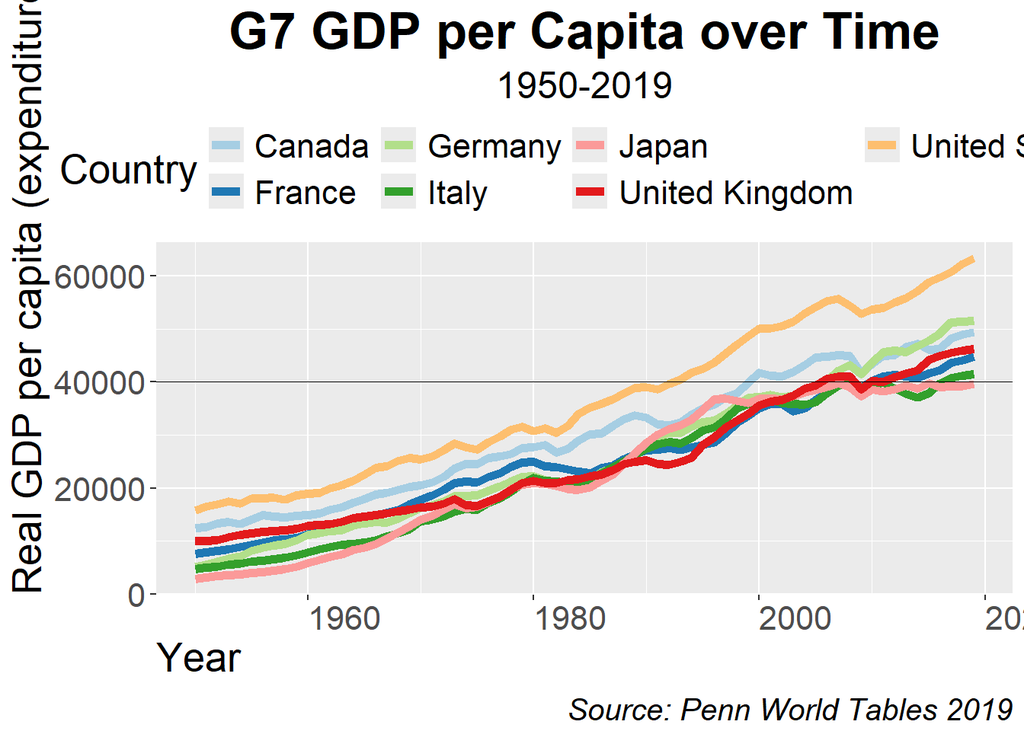

```r
line_plot <- ggplot(data = g7_data,
                aes(x = year,
                    y = rgdpe/pop,
                    fill = as_factor(country),
                    color = country)) +
        labs(x = "Year",
             y = "Real GDP per capita (expenditure-based)",
             fill = "Country",
             color = "Country",
             title = "G7 GDP per Capita over Time", subtitle = "1950-2019",
             caption = "Source: Penn World Tables 2019") +
        geom_line(size = 2) +
        theme(text = element_text(size = 18, hjust = 0)) +
        theme(text = element_text(size = 20, hjust = 0)) +
        theme(plot.title = element_text(size = 25, hjust = 0.5, color = "black", face = "bold")) +
        theme(plot.subtitle = element_text(size = 18, hjust = 0.5)) +
        theme(plot.caption = element_text(size = 15, face = "italic", vjust = 0)) +
        theme(legend.position = "top") +
        geom_hline(yintercept = 40000, linetype = "solid", size = 0.25) + # add horizontal line +
        scale_color_brewer(palette="Paired")
        options(repr.plot.width = 15, repr.plot.height = 9)

line_plot
```

We can see that this graph above, while it is quite consolidated, does not present the specific patterns of each country as clearly as does our faceted graph immediately before it.

### Confidence Bands

When creating visualizations that use a predictive element like a regression line, we can summon graph features that visualize how accurate our model is at predicting a variable(s) with 95% confidence.

The function `geom_smooth()` creates a trendline that aids the eye in spotting patterns in the data. Arguments within this function include:

- `method =` specifies the type of smoothing we want to use - in this notebook, we’ll use linear regression using the `lm` function
- `se =` uses a logical argument to specify the presence of a standard error/confidence band (default is `TRUE`)
- `color =` specifies the color of the trendline
- `fill =` specifies the color of the confidence band

## Part 3: Chart Design

Before we move into some case studies, we’ll examine a few more design tips and tricks that we can add to our visualization toolkit to make our visualizations look extra polished ✨

### Shapes

- `pch =` Allows us to change the shape of the data points using the argument on scatter plot to distinguish sets of data.
  - E.g., Option 2 (the upwards triangle icon) could indicate growth or movement upwards, whereas option 6 (the downwards triangle icon) could indicate decline or movement downwards.

The shape options are listed in the chart below - the default, as we’ve seen before, is 19, a simple circle. Note that numbers 21-25 are shapes that have both fill and outline color options which can be helpful if we are trying to make our data points stand out better. This is particularly useful if we are working with a large data set.

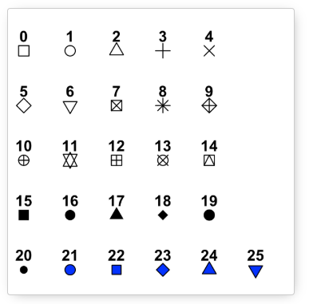

Geom point shape options

Try exploring a few different shape and size options in the scatterplot below!

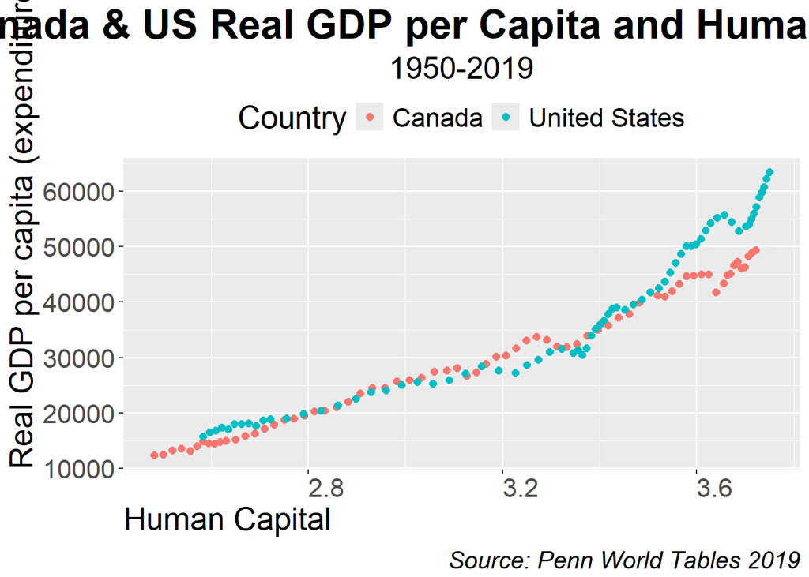

```r
intermediate_scatterplot <- ggplot(data = NA_data,
                aes(x = hc,
                    y = rgdpe/pop,
                    fill = country,
                    color = country,
                    geom_text(mapping = country))) +
        labs(x = "Human Capital",
             y = "Real GDP per capita (expenditure-based)",
             fill = "Country",
             color = "Country",
             title = "Canada & US Real GDP per Capita and Human Capital", subtitle = "1950-2019",
             caption = "Source: Penn World Tables 2019") +
        geom_point(pch = 19, size = 2) + # try exploring a few different shape and size options
        theme(text = element_text(size = 20, hjust = 0)) +
        theme(plot.title = element_text(size = 25, hjust = 0.5, color = "black", face = "bold")) +
        theme(plot.subtitle = element_text(size = 19, hjust = 0.5)) +
        theme(plot.caption = element_text(size = 15, face = "italic", vjust = 0)) +
        theme(legend.position = "top")
        options(repr.plot.width = 15, repr.plot.height = 9)

intermediate_scatterplot
```